# Comparative Analysis of Regularized and Kernel-Based Models in HR Analytics

Boning Liu

04-02-2025

# 1 Introduction

The purpose of this analysis is to investigate employee attrition and income patterns using machine learning techniques. Understanding the factors that influence whether an employee leaves a company (attrition) and what determines their income level is critical for human resources planning, talent retention, and organizational development.

This study uses the publicly available **IBM HR Analytics Employee Attrition & Performance** dataset, which includes a diverse range of employee characteristics, such as job role, age, education, marital status, job satisfaction, and performance indicators. The dataset contains 1,470 employee records and over 30 variables, a mix of categorical and continuous data.

The objective is twofold:

- First, to apply regularized linear regression (LASSO, Ridge, and Elastic Net) to predict **Monthly Income** and identify the most influential predictors.
- Second, to apply regularized logistic regression to predict the binary outcome **Attrition** (Yes/No) and evaluate model performance using ROC analysis.

The insights from this project can help organizations prioritize factors contributing to employee retention and compensation planning.

## 1.1 Dataset Overview

The dataset contains 35 variables that describe employee demographics, job characteristics, compensation, satisfaction ratings, and performance metrics. Below is a description of each variable, including its type and meaning:

- **Age** (Numerical): Age of the employee.
- **Attrition** (Categorical - Binary): Indicates whether the employee left the company (Yes/No).
- **BusinessTravel** (Categorical): Frequency of business travel (Non-Travel, Travel_Rarely, Travel_Frequently).
- **DailyRate** (Numerical): Daily income rate.
- **Department** (Categorical): Department name (Sales, Research & Development, Human Resources).
- **DistanceFromHome** (Numerical): Distance from home to workplace in kilometers.
- **Education** (Ordinal): Education level (1 = Below College, …, 5 = Doctorate).
- **EducationField** (Categorical): Field of education.
- **EmployeeCount** (Constant): Always 1 (not informative for modeling).
- **EmployeeNumber** (Identifier): Unique employee ID (excluded from modeling).
- **EnvironmentSatisfaction** (Ordinal): Satisfaction with the work environment (1 = Low to 4 = Very High).
- **Gender** (Categorical): Gender of the employee.
- **HourlyRate** (Numerical): Hourly wage.
- **JobInvolvement** (Ordinal): Level of job involvement (1 = Low to 4 = Very High).
- **JobLevel** (Ordinal): Job level within the organization.
- **JobRole** (Categorical): Specific job title or role.
- **JobSatisfaction** (Ordinal): Satisfaction with the job (1 = Low to 4 = Very High).
- **MaritalStatus** (Categorical): Marital status (Single, Married, Divorced).
- **MonthlyIncome** (Numerical): Monthly salary.
- **MonthlyRate** (Numerical): Monthly compensation rate.
- **NumCompaniesWorked** (Numerical): Number of companies the employee has previously worked for.
- **Over18** (Constant): Always Y (not useful for modeling).
- **OverTime** (Categorical): Indicates if the employee works overtime.
- **PercentSalaryHike** (Numerical): Percent increase in salary at last appraisal.
- **PerformanceRating** (Ordinal): Performance rating (1 = Low to 4 = Outstanding, though mostly 3 or 4).
- **RelationshipSatisfaction** (Ordinal): Satisfaction with relationships at work (1 = Low to 4 = Very High).
- **StandardHours** (Constant): Always 80 (not informative).
- **StockOptionLevel** (Ordinal): Level of stock options granted.
- **TotalWorkingYears** (Numerical): Total years of professional experience.
- **TrainingTimesLastYear** (Numerical): Number of training events attended in the past year.
- **WorkLifeBalance** (Ordinal): Work-life balance rating (1 = Bad to 4 = Best).
- **YearsAtCompany** (Numerical): Total years with the current company.
- **YearsInCurrentRole** (Numerical): Years in the current job role.
- **YearsSinceLastPromotion** (Numerical): Years since the last promotion.
- **YearsWithCurrManager** (Numerical): Years under the current manager.

Variables such as **EmployeeCount**, **Over18**, **StandardHours**, and **EmployeeNumber** are constants or identifiers and will be **removed** during preprocessing.

# 2 Data Preparation

## 2.1 Loading the Dataset

## 2.2 Checking for Missing Values

```r
# Check for missing values in each column
missing_values <- sapply(df, function(x) sum(is.na(x)))
missing_values[missing_values > 0]  # should return nothing if there are no missing values
```

```
named integer(0)
```

There are no missing values in the dataset, so no imputation is required at this stage.

## 2.3 Summarizing Numerical Variables

```r
# Select numerical columns and get summary statistics
numerical_vars <- df %>% select_if(is.numeric)
summary(numerical_vars)
```

```
      Age          DailyRate      DistanceFromHome   Education
 Min.   :18.00   Min.   : 102.0   Min.   : 1.000   Min.   :1.000
 1st Qu.:30.00   1st Qu.: 465.0   1st Qu.: 2.000   1st Qu.:2.000
 Median :36.00   Median : 802.0   Median : 7.000   Median :3.000
 Mean   :36.92   Mean   : 802.5   Mean   : 9.193   Mean   :2.913
 3rd Qu.:43.00   3rd Qu.:1157.0   3rd Qu.:14.000   3rd Qu.:4.000
 Max.   :60.00   Max.   :1499.0   Max.   :29.000   Max.   :5.000
 EmployeeCount EmployeeNumber   EnvironmentSatisfaction   HourlyRate
 Min.   :1     Min.   :   1.0   Min.   :1.000           Min.   : 30.00
 1st Qu.:1     1st Qu.: 491.2   1st Qu.:2.000           1st Qu.: 48.00
 Median :1     Median :1020.5   Median :3.000           Median : 66.00
 Mean   :1     Mean   :1024.9   Mean   :2.722           Mean   : 65.89
 3rd Qu.:1     3rd Qu.:1555.8   3rd Qu.:4.000           3rd Qu.: 83.75
 Max.   :1     Max.   :2068.0   Max.   :4.000           Max.   :100.00
 JobInvolvement    JobLevel     JobSatisfaction MonthlyIncome    MonthlyRate
 Min.   :1.00   Min.   :1.000   Min.   :1.000   Min.   : 1009   Min.   : 2094
 1st Qu.:2.00   1st Qu.:1.000   1st Qu.:2.000   1st Qu.: 2911   1st Qu.: 8047
 Median :3.00   Median :2.000   Median :3.000   Median : 4919   Median :14236
 Mean   :2.73   Mean   :2.064   Mean   :2.729   Mean   : 6503   Mean   :14313
 3rd Qu.:3.00   3rd Qu.:3.000   3rd Qu.:4.000   3rd Qu.: 8379   3rd Qu.:20462
 Max.   :4.00   Max.   :5.000   Max.   :4.000   Max.   :19999   Max.   :26999
 NumCompaniesWorked PercentSalaryHike PerformanceRating
 Min.   :0.000      Min.   :11.00     Min.   :3.000
 1st Qu.:1.000      1st Qu.:12.00     1st Qu.:3.000
 Median :2.000      Median :14.00     Median :3.000
 Mean   :2.693      Mean   :15.21     Mean   :3.154
 3rd Qu.:4.000      3rd Qu.:18.00     3rd Qu.:3.000
 Max.   :9.000      Max.   :25.00     Max.   :4.000
 RelationshipSatisfaction StandardHours StockOptionLevel TotalWorkingYears
 Min.   :1.000            Min.   :80    Min.   :0.0000   Min.   : 0.00
 1st Qu.:2.000            1st Qu.:80    1st Qu.:0.0000   1st Qu.: 6.00
 Median :3.000            Median :80    Median :1.0000   Median :10.00
 Mean   :2.712            Mean   :80    Mean   :0.7939   Mean   :11.28
 3rd Qu.:4.000            3rd Qu.:80    3rd Qu.:1.0000   3rd Qu.:15.00
 Max.   :4.000            Max.   :80    Max.   :3.0000   Max.   :40.00
 TrainingTimesLastYear WorkLifeBalance YearsAtCompany   YearsInCurrentRole
 Min.   :0.000         Min.   :1.000   Min.   : 0.000   Min.   : 0.000
 1st Qu.:2.000         1st Qu.:2.000   1st Qu.: 3.000   1st Qu.: 2.000
 Median :3.000         Median :3.000   Median : 5.000   Median : 3.000
 Mean   :2.799         Mean   :2.761   Mean   : 7.008   Mean   : 4.229
 3rd Qu.:3.000         3rd Qu.:3.000   3rd Qu.: 9.000   3rd Qu.: 7.000
 Max.   :6.000         Max.   :4.000   Max.   :40.000   Max.   :18.000
 YearsSinceLastPromotion YearsWithCurrManager
 Min.   : 0.000          Min.   : 0.000
 1st Qu.: 0.000          1st Qu.: 2.000
 Median : 1.000          Median : 3.000
 Mean   : 2.188          Mean   : 4.123
 3rd Qu.: 3.000          3rd Qu.: 7.000
 Max.   :15.000          Max.   :17.000
```

- No invalid placeholder values (e.g., -1) were found in any columns.
- **StandardHours**, **EmployeeCount**, and **Over18** are constants and will be removed.
- Some variables such as **MonthlyIncome**, **TotalWorkingYears**, and **YearsAtCompany** show skewness and may benefit from transformations (e.g., log-scale).

## 2.4 Summarizing Categorical Variables

```r
# Select categorical columns and count number of unique levels
categorical_vars <- df %>% select_if(is.character)
sapply(categorical_vars, function(x) length(unique(x)))
```

```
     Attrition BusinessTravel     Department EducationField         Gender
             2              3              3              6              2
       JobRole  MaritalStatus         Over18       OverTime
             9              3              1              2
```

- **JobRole** and **EducationField** contain a diverse range of categories that may be useful for predictive modeling.
- **Attrition**, **Gender**, and **OverTime** are binary variables suitable for logistic regression.
- **Over18** has only one unique value and will be removed from the dataset during preprocessing.

## 2.5 Removing Irrelevant Variables

The following variables were removed as they do not provide any predictive value:

- **Over18**: Constant value “Y”
- **StandardHours**: Constant value 80
- **EmployeeCount**: Constant value 1
- **EmployeeNumber**: Unique identifier

These variables were either constant across all records or non-informative for modeling.

## 2.6 Encoding Categorical Variables

All categorical variables were converted into dummy variables using **model.matrix()**, which produces a numeric design matrix compatible with **glmnet**. The response variable **Attrition** was encoded as a binary factor (**1 = Yes**, **0 = No**) for logistic regression. The response variable **MonthlyIncome** was retained as-is for linear regression.

The final dataset contains only numeric features and is ready for regularized modeling.

# 3 Regularized Linear Regression

## 3.1 Set Up for Modeling

## 3.2 LASSO Regression (alpha = 1)

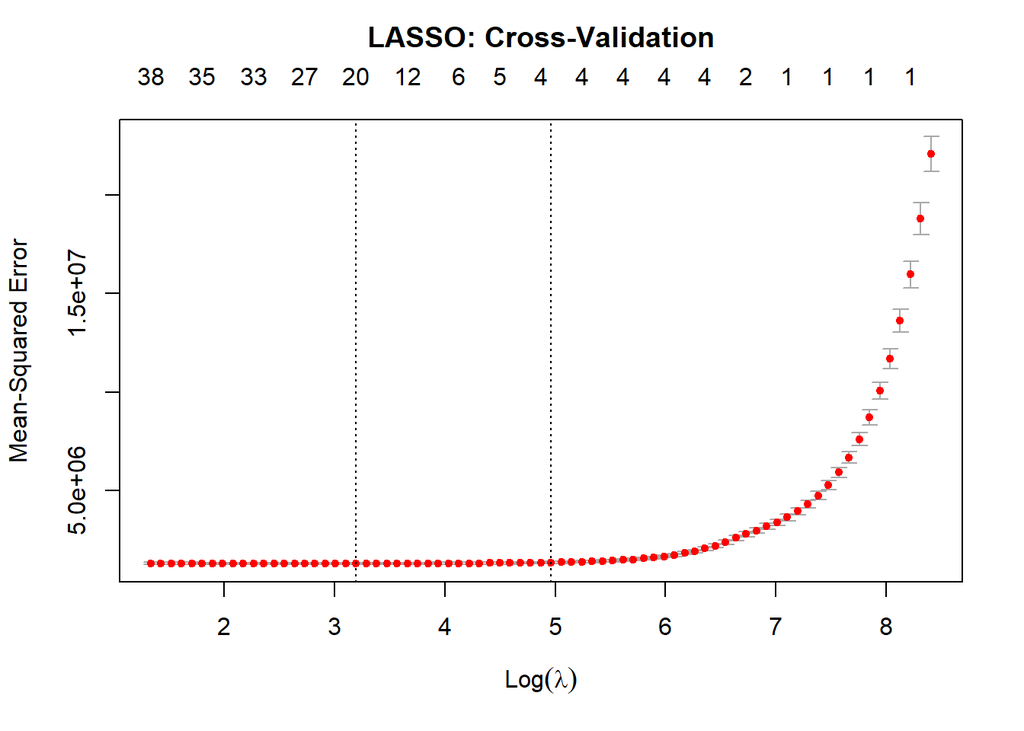

```r
# Remove MonthlyIncome from predictors
df_lm <- df_clean %>% select(-MonthlyIncome)

# Create model matrix for predictors
x <- model.matrix(Attrition ~ . -1, data = df_lm)

# Define response variable
y_linear <- df_clean$MonthlyIncome

# Run LASSO with cross-validation
set.seed(123)
cv_lasso <- cv.glmnet(x, y_linear, alpha = 1)

# Plot CV error vs lambda
plot(cv_lasso)
title("LASSO: Cross-Validation", line = 2.5)
```

```r
# Extract best lambda and coefficients
best_lambda_lasso <- cv_lasso$lambda.min
coef(cv_lasso, s = "lambda.min")
```

```
45 x 1 sparse Matrix of class "dgCMatrix"
                                            s1
(Intercept)                      -1.322774e+02
Age                               .
BusinessTravelNon-Travel         -7.684096e+01
BusinessTravelTravel_Frequently   .
BusinessTravelTravel_Rarely       4.722708e+00
DailyRate                         3.158439e-02
DepartmentResearch & Development  .
DepartmentSales                   .
DistanceFromHome                 -1.777027e+00
Education                         .
EducationFieldLife Sciences       .
EducationFieldMarketing           .
EducationFieldMedical             .
EducationFieldOther               .
EducationFieldTechnical Degree    .
EnvironmentSatisfaction           .
GenderMale                        2.981495e+01
HourlyRate                        2.132056e-01
JobInvolvement                   -5.246423e+01
JobLevel                          2.880392e+03
JobRoleHuman Resources            .
JobRoleLaboratory Technician     -3.279301e+02
JobRoleManager                    3.969055e+03
JobRoleManufacturing Director     .
JobRoleResearch Director          3.893690e+03
JobRoleResearch Scientist        -2.221421e+02
JobRoleSales Executive            .
JobRoleSales Representative      -3.391019e+02
JobSatisfaction                   .
MaritalStatusMarried              .
MaritalStatusSingle               .
MonthlyRate                      -7.704143e-04
NumCompaniesWorked                2.748119e+00
OverTimeYes                       1.395567e+01
PercentSalaryHike                 .
PerformanceRating                 .
RelationshipSatisfaction          .
StockOptionLevel                  .
TotalWorkingYears                 3.936148e+01
TrainingTimesLastYear            -2.234272e+00
WorkLifeBalance                   .
YearsAtCompany                    .
YearsInCurrentRole                .
YearsSinceLastPromotion           1.323406e+01
YearsWithCurrManager             -8.793394e+00
```

LASSO regression was applied to model **MonthlyIncome** using all other predictors. After removing the response from the input matrix and applying cross-validation, the optimal lambda was selected based on the minimum mean squared error.

The model suggests that job position and experience are the strongest contributors to income differences.

## 3.3 Ridge Regression (alpha = 0)

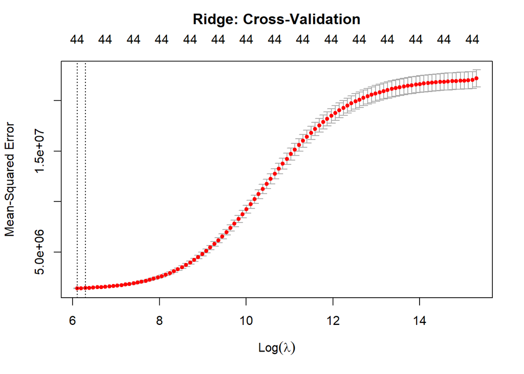

```r
# Set seed for reproducibility
set.seed(123)

# Perform cross-validation to select optimal lambda for Ridge
cv_ridge <- cv.glmnet(x, y_linear, alpha = 0)

# Plot CV error vs lambda
plot(cv_ridge)
title("Ridge: Cross-Validation", line = 2.5)
```

```r
# Extract best lambda and coefficient estimates
best_lambda_ridge <- cv_ridge$lambda.min
coef(cv_ridge, s = "lambda.min")
```

```
45 x 1 sparse Matrix of class "dgCMatrix"
                                            s1
(Intercept)                       1.662454e+03
Age                               2.501375e+00
BusinessTravelNon-Travel         -1.300417e+02
BusinessTravelTravel_Frequently   1.777951e+01
BusinessTravelTravel_Rarely       4.517200e+01
DailyRate                         7.975453e-02
DepartmentResearch & Development  1.439022e+01
DepartmentSales                  -3.417245e+01
DistanceFromHome                 -3.728071e+00
Education                        -1.808495e+01
EducationFieldLife Sciences      -3.023021e+01
EducationFieldMarketing           3.710218e+01
EducationFieldMedical            -5.847857e+01
EducationFieldOther              -8.291156e+01
EducationFieldTechnical Degree    2.460792e+01
EnvironmentSatisfaction          -1.978784e+00
GenderMale                        9.021523e+01
HourlyRate                        5.463335e-01
JobInvolvement                   -9.269940e+01
JobLevel                          2.084592e+03
JobRoleHuman Resources           -7.306081e+02
JobRoleLaboratory Technician     -1.114288e+03
JobRoleManager                    4.426732e+03
JobRoleManufacturing Director    -9.035804e+01
JobRoleResearch Director          4.304120e+03
JobRoleResearch Scientist        -1.057571e+03
JobRoleSales Executive           -7.004820e+01
JobRoleSales Representative      -1.130309e+03
JobSatisfaction                  -5.531861e+00
MaritalStatusMarried              3.431559e+01
MaritalStatusSingle              -3.174238e+01
MonthlyRate                      -3.332945e-03
NumCompaniesWorked                1.303097e+01
OverTimeYes                       6.048882e+01
PercentSalaryHike                 1.175738e+01
PerformanceRating                -1.504846e+02
RelationshipSatisfaction          1.680905e+01
StockOptionLevel                 -3.981093e+01
TotalWorkingYears                 7.844170e+01
TrainingTimesLastYear            -1.871669e+01
WorkLifeBalance                   1.604709e+00
YearsAtCompany                    1.995373e+01
YearsInCurrentRole               -7.628003e-01
YearsSinceLastPromotion           2.722468e+01
YearsWithCurrManager             -2.959576e+01
```

- The minimum mean squared error is reached at around log(λ) ≈ 6.1
- All 44 predictors are retained (as expected for Ridge)
- Ridge regression was performed with α = 0 to apply L2 regularization. Using 10-fold cross-validation, the optimal λ was selected to minimize mean squared error.
- Unlike LASSO, Ridge retains all predictors, but applies shrinkage to reduce overfitting. Key predictors such as **JobRoleManager**, **JobRoleResearch Director**, **JobLevel**, and **TotalWorkingYears** had the largest positive impact on predicted salary. Negative associations were observed for roles like **Sales Representative** and **Laboratory Technician**.

This model is useful when many variables contribute small effects, and when full model interpretability is not required.

## 3.4 Elastic Net Regression (alpha = 0.5)

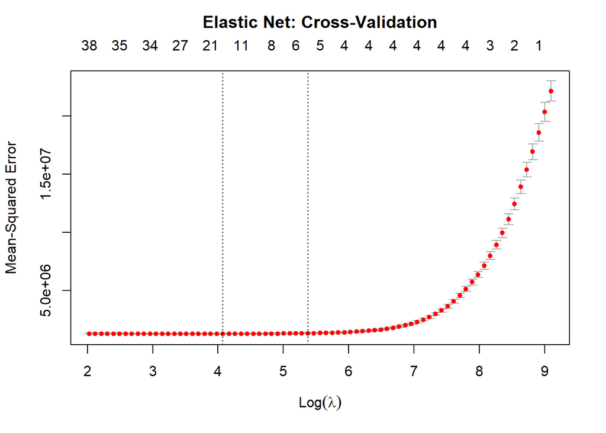

```r
# Set seed for reproducibility
set.seed(123)

# Elastic Net with alpha = 0.5
cv_elastic <- cv.glmnet(x, y_linear, alpha = 0.5)

# Plot CV error vs lambda
plot(cv_elastic)
title("Elastic Net: Cross-Validation", line = 2.5)
```

```r
# Extract best lambda and coefficients
best_lambda_elastic <- cv_elastic$lambda.min
coef(cv_elastic, s = "lambda.min")
```

```
45 x 1 sparse Matrix of class "dgCMatrix"
                                            s1
(Intercept)                       -54.32744454
Age                                 .
BusinessTravelNon-Travel          -62.29730656
BusinessTravelTravel_Frequently     .
BusinessTravelTravel_Rarely         .
DailyRate                           0.01894838
DepartmentResearch & Development    .
DepartmentSales                     .
DistanceFromHome                   -1.11916028
Education                           .
EducationFieldLife Sciences         .
EducationFieldMarketing             .
EducationFieldMedical               .
EducationFieldOther                 .
EducationFieldTechnical Degree      .
EnvironmentSatisfaction             .
GenderMale                         18.93976104
HourlyRate                          .
JobInvolvement                    -45.34621016
JobLevel                         2817.69642802
JobRoleHuman Resources              .
JobRoleLaboratory Technician     -360.61851716
JobRoleManager                   3994.97423031
JobRoleManufacturing Director       .
JobRoleResearch Director         3910.13077525
JobRoleResearch Scientist        -257.17103531
JobRoleSales Executive              .
JobRoleSales Representative      -354.96128322
JobSatisfaction                     .
MaritalStatusMarried                .
MaritalStatusSingle                 .
MonthlyRate                         .
NumCompaniesWorked                  1.11990865
OverTimeYes                         3.17345058
PercentSalaryHike                   .
PerformanceRating                   .
RelationshipSatisfaction            .
StockOptionLevel                    .
TotalWorkingYears                  43.78765858
TrainingTimesLastYear               .
WorkLifeBalance                     .
YearsAtCompany                      .
YearsInCurrentRole                  .
YearsSinceLastPromotion            11.26342118
YearsWithCurrManager               -5.39481656
```

Elastic Net regression was applied using α = 0.5, blending LASSO and Ridge penalties. This hybrid approach enables both variable selection and coefficient shrinkage, making it ideal when predictors are potentially correlated.

# 4 Regularized Logistic Regression (Attrition prediction)

## 4.1 LASSO Logistic Regression (alpha = 1)

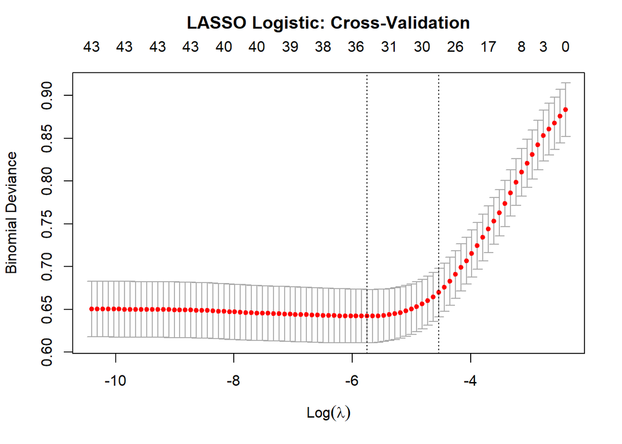

```r
# Load required packages
library(pROC)

# Set seed for reproducibility
set.seed(123)

# Run LASSO logistic regression
cv_lasso_logit <- cv.glmnet(x, y_logistic, alpha = 1, family = "binomial")

# Plot cross-validation results
plot(cv_lasso_logit)
title("LASSO Logistic: Cross-Validation", line = 2.5)
```

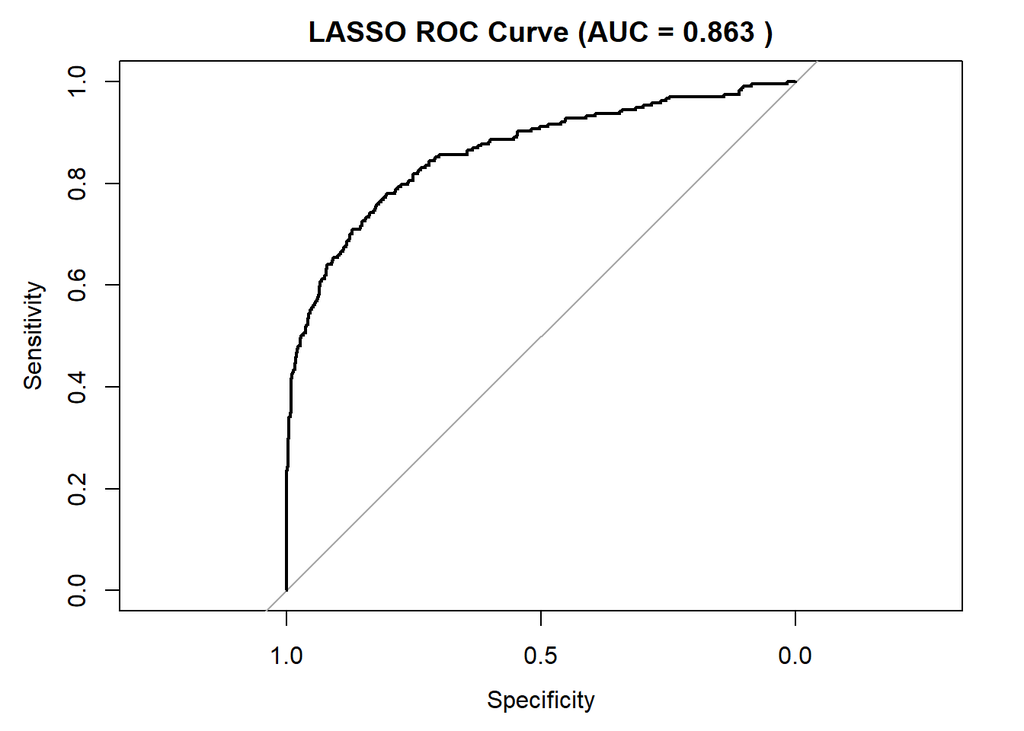

```r
# Predict probabilities using best lambda
pred_probs_lasso <- predict(cv_lasso_logit, newx = x, s = "lambda.min", type = "response")

# Compute ROC and AUC
roc_lasso <- roc(y_logistic, as.vector(pred_probs_lasso))
auc_lasso <- auc(roc_lasso)

# Plot ROC
plot(roc_lasso, main = paste("LASSO ROC Curve (AUC =", round(auc_lasso, 3), ")"))
```

LASSO logistic regression was applied to model the binary outcome **Attrition**. The optimal penalty (λ) was selected through cross-validation, minimizing binomial deviance.

This model can help identify key risk factors for employee attrition while avoiding overfitting.

## 4.2 Ridge Logistic Regression (alpha = 0)

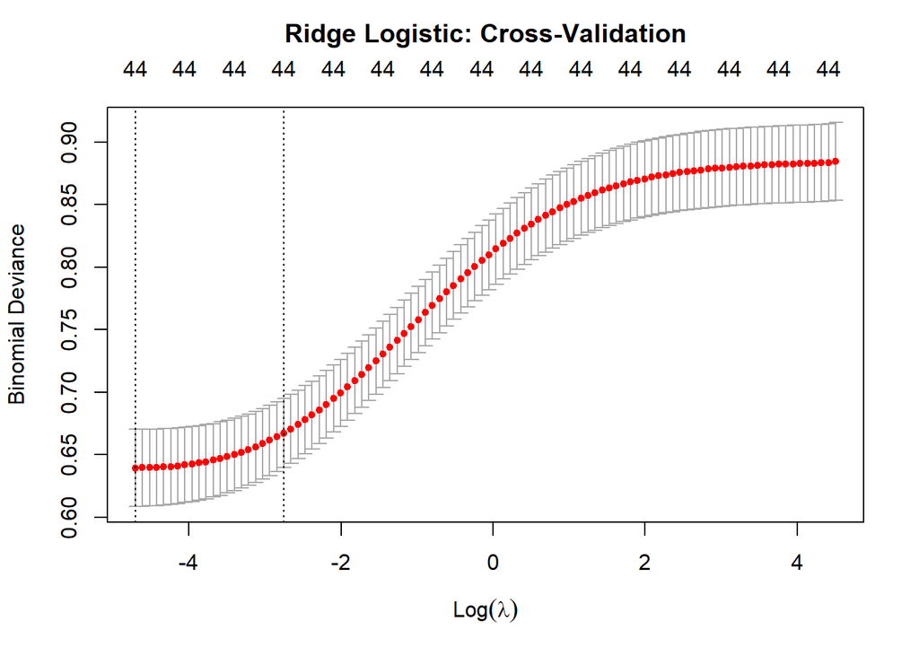

```r
# Set seed for reproducibility
set.seed(123)

# Ridge logistic regression (alpha = 0)
cv_ridge_logit <- cv.glmnet(x, y_logistic, alpha = 0, family = "binomial")

# Plot cross-validation results
plot(cv_ridge_logit)
title("Ridge Logistic: Cross-Validation", line = 2.5)
```

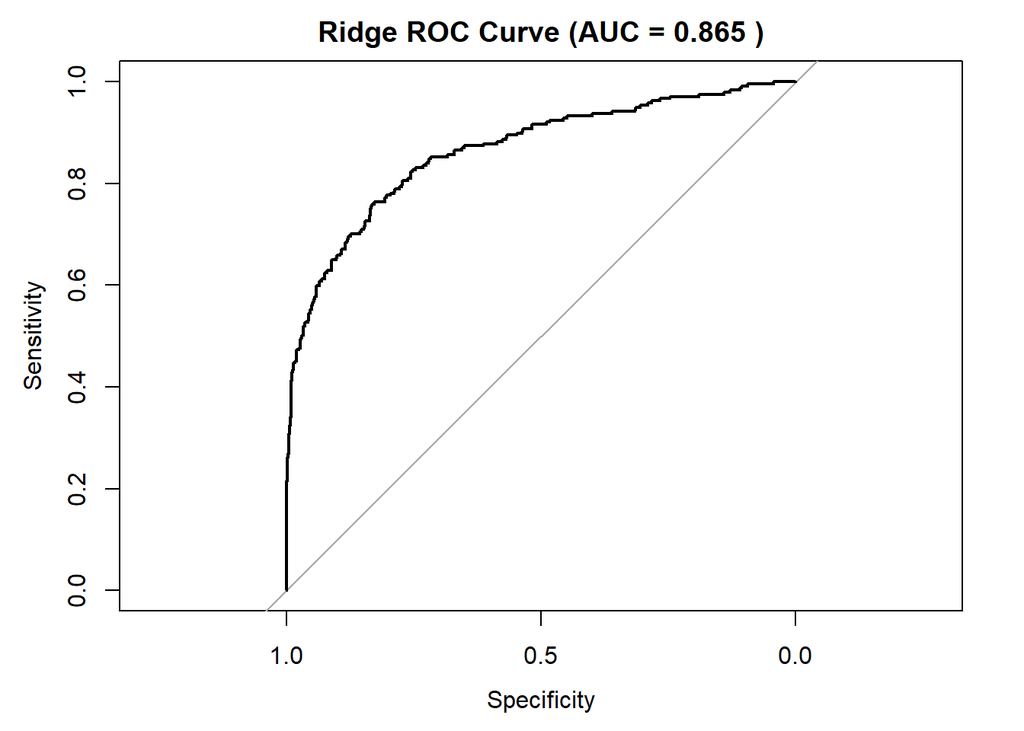

```r
# Predict probabilities
pred_probs_ridge <- predict(cv_ridge_logit, newx = x, s = "lambda.min", type = "response")

# Compute ROC and AUC
roc_ridge <- roc(y_logistic, as.vector(pred_probs_ridge))
auc_ridge <- auc(roc_ridge)

# Plot ROC
plot(roc_ridge, main = paste("Ridge ROC Curve (AUC =", round(auc_ridge, 3), ")"))
```

Ridge logistic regression was used to model employee attrition with α = 0, applying L2 regularization. This method retains all predictors, shrinking their coefficients to reduce overfitting.

The optimal penalty parameter was selected via cross-validation. The model achieved an AUC of **0.865**, slightly outperforming LASSO while maintaining all predictors. This approach offers strong predictive accuracy and is particularly valuable when predictors are correlated or when full variable retention is desired.

## 4.3 Elastic Net Logistic Regression (alpha = 0.5)

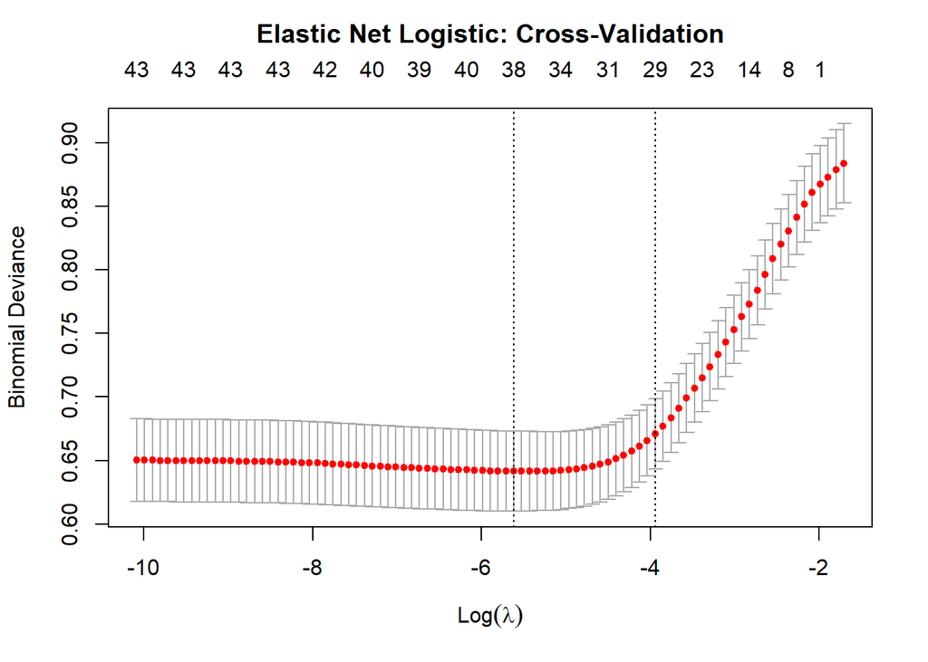

```r
# Set seed for reproducibility
set.seed(123)

# Elastic Net logistic regression (alpha = 0.5)
cv_elastic_logit <- cv.glmnet(x, y_logistic, alpha = 0.5, family = "binomial")

# Plot CV deviance
plot(cv_elastic_logit)
title("Elastic Net Logistic: Cross-Validation", line = 2.5)
```

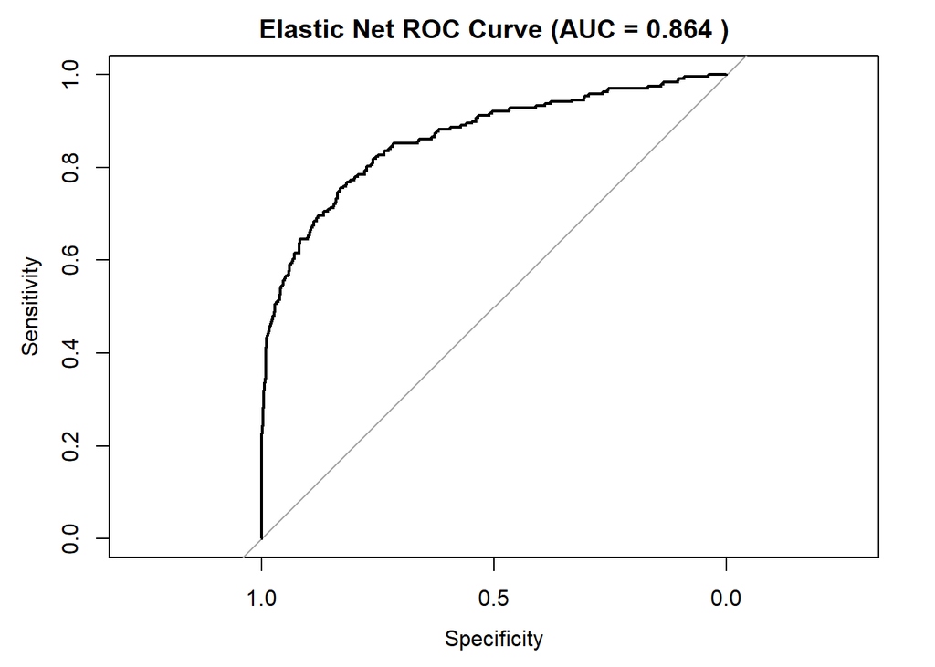

```r
# Predict probabilities at optimal lambda
pred_probs_elastic <- predict(cv_elastic_logit, newx = x, s = "lambda.min", type = "response")

# Compute ROC and AUC
roc_elastic <- roc(y_logistic, as.vector(pred_probs_elastic))
auc_elastic <- auc(roc_elastic)

# Plot ROC curve
plot(roc_elastic, main = paste("Elastic Net ROC Curve (AUC =", round(auc_elastic, 3), ")"))
```

Elastic Net logistic regression was applied using α = 0.5, combining LASSO’s variable selection with Ridge’s coefficient shrinkage.

The model achieved an AUC of **0.864**, showing excellent discriminatory power. It retained a subset of predictors that balance interpretability and robustness, offering a flexible compromise between the sparse LASSO model and the full Ridge model.

# 5 Part 2: SVM Regression (Linear Kernel)

```r
# Load necessary package
library(e1071)

# Set seed for reproducibility
set.seed(123)

# Train SVM regression model with linear kernel
svm_linear_reg <- svm(x, y_linear, kernel = "linear", type = "eps-regression")

# Predict on training data (since no test split yet)
pred_svm_linear <- predict(svm_linear_reg, x)

# Evaluate performance
mse_svm_linear <- mean((y_linear - pred_svm_linear)^2)
mae_svm_linear <- mean(abs(y_linear - pred_svm_linear))

# Output results
mse_svm_linear
```

```
[1] 1251311
```

```r
mae_svm_linear
```

```
[1] 833.3249
```

A Support Vector Regression (SVR) model with a linear kernel was used to predict **MonthlyIncome**. The model was trained on the full dataset, and prediction performance was evaluated using:

- **Mean Squared Error (MSE)**: 1,251,311
- **Mean Absolute Error (MAE)**: 833.32

These metrics will be compared against the results from regularized linear models and other SVM kernels in later sections.

## 5.1 SVM Regression – RBF Kernel

```r
# Set seed for reproducibility
set.seed(123)

# Train SVM regression with RBF kernel
svm_rbf_reg <- svm(x, y_linear, kernel = "radial", type = "eps-regression")

# Predict on training data
pred_svm_rbf <- predict(svm_rbf_reg, x)

# Evaluate performance
mse_svm_rbf <- mean((y_linear - pred_svm_rbf)^2)
mae_svm_rbf <- mean(abs(y_linear - pred_svm_rbf))

# Output MSE and MAE
mse_svm_rbf
```

```
[1] 386974.4
```

```r
mae_svm_rbf
```

```
[1] 489.9704
```

A Support Vector Regression (SVR) model with an RBF (Radial Basis Function) kernel was fitted to predict **MonthlyIncome**. This kernel allows for nonlinear relationships between predictors and the response variable.

Performance metrics were:

- **Mean Squared Error (MSE)**: 386,974
- **Mean Absolute Error (MAE)**: 489.97

These results show a substantial improvement over the linear SVM model, indicating that nonlinear effects are important in modeling employee salary.

## 5.2 SVM Classification (Linear Kernel)

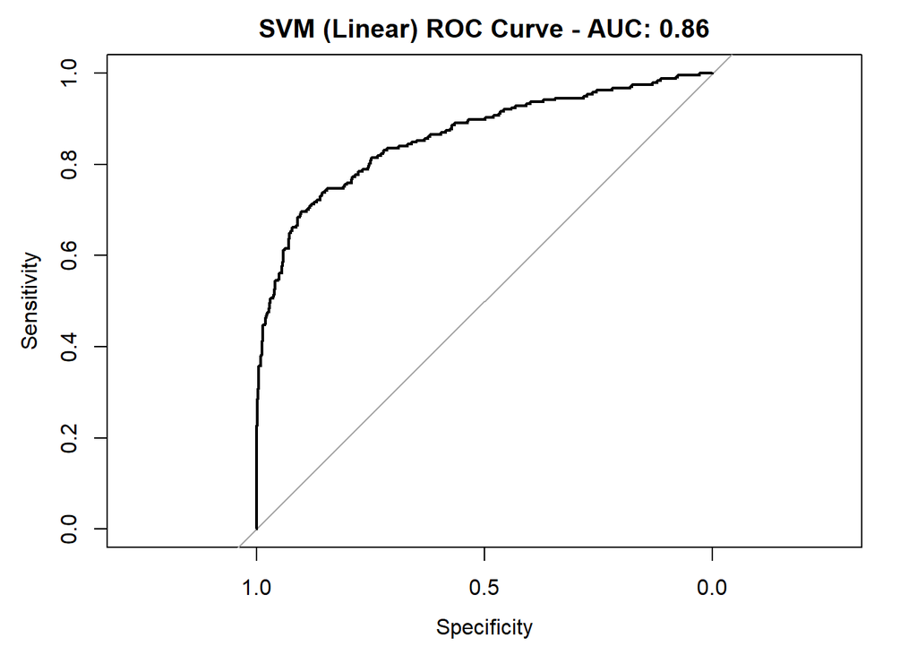

```r
# Set seed for reproducibility
set.seed(123)

# Train SVM classification model with linear kernel
svm_linear_cls <- svm(x, as.factor(y_logistic), kernel = "linear", type = "C-classification", probability = TRUE)

# Predict probabilities and class labels
pred_linear_cls <- predict(svm_linear_cls, x, probability = TRUE)
prob_linear <- attr(pred_linear_cls, "probabilities")[, "1"]

# ROC and AUC
roc_linear_svm <- roc(y_logistic, prob_linear)
auc_linear_svm <- auc(roc_linear_svm)

# Plot ROC
plot(roc_linear_svm, main = paste("SVM (Linear) ROC Curve - AUC:", round(auc_linear_svm, 3)))
```

Support Vector Machine (SVM) classification with a linear kernel was applied to predict **Attrition**. The model was trained using the same predictor matrix as in previous models.

The ROC curve for this model yielded an AUC of **0.860**, indicating strong performance in distinguishing between employees who stayed and those who left. While slightly behind the regularized logistic regression models in AUC, linear SVM remains competitive in predictive power and generalization.

## 5.3 SVM Classification – RBF Kernel

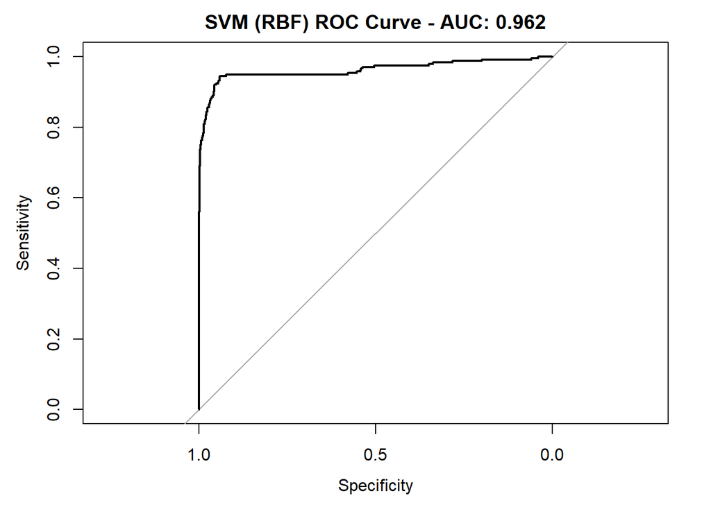

```r
# Set seed for reproducibility
set.seed(123)

# Train SVM with RBF kernel
svm_rbf_cls <- svm(x, as.factor(y_logistic), kernel = "radial", type = "C-classification", probability = TRUE)

# Predict probabilities and class labels
pred_rbf_cls <- predict(svm_rbf_cls, x, probability = TRUE)
prob_rbf <- attr(pred_rbf_cls, "probabilities")[, "1"]

# ROC and AUC
roc_rbf_svm <- roc(y_logistic, prob_rbf)
auc_rbf_svm <- auc(roc_rbf_svm)

# Plot ROC
plot(roc_rbf_svm, main = paste("SVM (RBF) ROC Curve - AUC:", round(auc_rbf_svm, 3)))
```

An SVM classifier with a Radial Basis Function (RBF) kernel was applied to predict **Attrition**. This kernel captures complex nonlinear relationships between the predictors and the response.

The model achieved an AUC of **0.962**, significantly outperforming all other classification models, including LASSO, Ridge, Elastic Net, and linear SVM. These results indicate that nonlinear decision boundaries are highly effective for modeling employee attrition patterns.

# 6 Model Comparison & Evaluation

This section compares the performance of all models implemented throughout the project, across both regression and classification tasks. Evaluation metrics were used to assess prediction accuracy and model effectiveness, with a focus on Mean Squared Error (MSE) and Mean Absolute Error (MAE) for regression, and Area Under the ROC Curve (AUC) for classification.

## 6.2 Classification Task – Predicting Attrition

For the binary classification of employee attrition, all models performed well, with AUC scores ranging from 0.860 to 0.865 for LASSO, Ridge, Elastic Net, and linear SVM. These models demonstrated strong discriminatory power and produced consistent results.

However, the SVM with an RBF kernel clearly outperformed all others, achieving an AUC of 0.962. This dramatic improvement indicates that nonlinear modeling is highly effective for capturing the underlying structure of attrition risk. It suggests that employee attrition is influenced by complex, nonlinear patterns across features — which RBF kernels are able to model effectively.

Overall, the RBF-based SVM models emerged as the most accurate and powerful methods across both tasks, significantly improving performance without the need for manual feature selection or complex preprocessing.

# 7 Conclusion

#### 7.0.0.1 7. Conclusion

This project explored multiple machine learning methods to address two primary goals: predicting employee monthly income (regression) and identifying individuals likely to leave the organization (classification). Regularized linear and logistic regression techniques were first applied, followed by Support Vector Machine (SVM) models using both linear and nonlinear (RBF) kernels.

For classification, while regularized logistic regression and linear SVM models performed well (AUC ~0.86), the RBF SVM model achieved an AUC of 0.962. This dramatic increase in performance highlights the importance of nonlinear modeling for detecting patterns in employee attrition risk.